# System Usability Scale

## Load necessary packages

```r
library(WRS2)
library(rcompanion)
library(feather)
library(ggplot2)
library(plyr)
library(ez)
library(schoRsch)
library(MASS)
library(car)
library(tidyverse)
library(ggpubr)
library(rstatix)
library(here)
```

## Load the data

We are loading the experimental data in wide format.

```r
df_wide <- read_feather(path = here('../../data_frames/results_test_18-03-2020.file'))
```

[output not shown]

## Prepare the data

### Assign participants to the experimental group

- version 1 and 2 –> control group
- version 3 und 4 –> experimental group context free
- version 5 und 6–> experimental group context sensitive

```r
df_wide$group <- ifelse((df_wide$version == 5 | df_wide$version == 6), 'context-sensitive experimental group', ifelse((df_wide$version == 1 | df_wide$version == 2), 'controlgroup', 'context-free experimental group'))
```

```r
# Check if the design is balanced
table(df_wide$group)
```

```
     context-free experimental group context-sensitive experimental group                         controlgroup
                                  13                                   21                                   21
```

```r
# Convert trial, group and subject number to factors in each dataframe
df_wide$group <- factor(df_wide$group)
df_wide$partnr <- factor(df_wide$partnr)
```

## Data Analysis: System Usability scale

#### Are there differences between the groups?

Computing Kruskal-Wallis rank sum test yields no significant differences.

```r
tapply(df_wide$SUS, df_wide$group, mean)
```

```
     context-free experimental group context-sensitive experimental group                         controlgroup
                            52.11538                             50.35714                             49.40476
```

```r
tapply(df_wide$SUS, df_wide$group, sd)
```

```
     context-free experimental group context-sensitive experimental group                         controlgroup
                            15.90487                             20.02008                             16.14204
```

```r
mean(df_wide$SUS)
```

```
[1] 50.40909
```

```r
sd(df_wide$SUS)
```

```
[1] 17.38563
```

```r
kruskal.test(df_wide$SUS ~ df_wide$group)
```

```
    Kruskal-Wallis rank sum test

data:  df_wide$SUS by df_wide$group
Kruskal-Wallis chi-squared = 0.11974, df = 2, p-value = 0.9419
```

#### Are there differences between the versions?

Computing Kruskal-Wallis rank sum test yields no significant differences.

```r
tapply(df_wide$SUS, df_wide$version, mean)
```

```
       1        2        3        4        5        6
49.77273 49.00000 52.50000 51.78571 42.00000 57.95455
```

```r
kruskal.test(df_wide$SUS ~ df_wide$version)
```

```
    Kruskal-Wallis rank sum test

data:  df_wide$SUS by df_wide$version
Kruskal-Wallis chi-squared = 4.1257, df = 5, p-value = 0.5315
```

#### How many participants in the experimental groups gave the system a “positive” rating (> 71.4)?

Only four participants rated the prorotpye above 71.4.

```r
df_exp <- df_wide[!(df_wide$group=="controlgroup"), ]
df_exp$SUS_above_average <- ifelse((df_exp$SUS > 71.4), 1, 0)
df_exp$SUS_above_average <- as.factor(df_exp$SUS_above_average)
df_exp %>%
  count(SUS_above_average)
```

| SUS_above_average | n |
| --- | --- |
| 0 | 30 |
| 1 | 4 |

###### boxplots

```
`fun.y` is deprecated. Use `fun` instead.
```

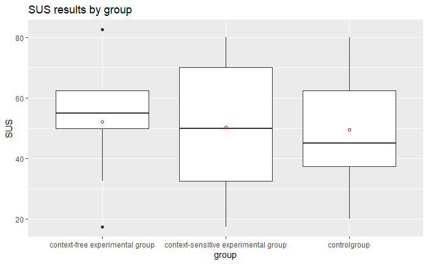

```r
ggplot(df_wide,aes(x = group, y=SUS) ) +
  geom_boxplot() +
  stat_summary(fun.y=mean,shape=1,col='red',geom='point') +
  labs(x="group",
       y = "SUS",
       title="SUS results by group")
```

### Relation with NASA-TLX

Correlate SUS score and NASA-TLX mean (n.s.). Since the boxplots show some outliers, we compute robust correlation rather than pearson correlation. Trend: the higher the perceived system usability, the lower the perceived mental workload.

```r
df_wide$NASATLX_mean <-  rowMeans(df_wide[c('NASATLX_1', 'NASATLX_4', 'NASATLX_3', 'NASATLX_4')], na.rm=TRUE)
pbcor(df_wide$SUS,df_wide$NASATLX_mean)
```

```
Call:
pbcor(x = df_wide$SUS, y = df_wide$NASATLX_mean)

Robust correlation coefficient: -0.2049
Test statistic: -1.5237
p-value: 0.13353
```

There is a significant negative correlation with NASA-TLX before interruption (p = .019)

```r
pbcor(df_wide$SUS,df_wide$NASATLX_1)
```

```
Call:
pbcor(x = df_wide$SUS, y = df_wide$NASATLX_1)

Robust correlation coefficient: -0.315
Test statistic: -2.4164
p-value: 0.01915
```

```
integer(0)
```

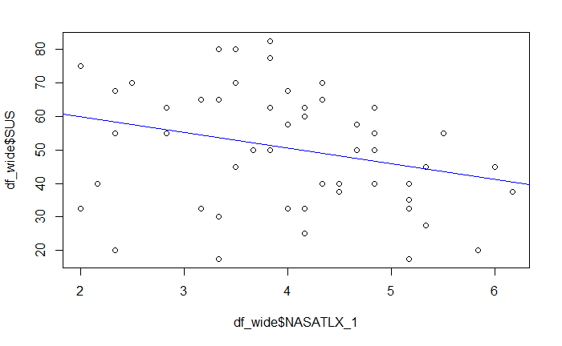

```r
plot(df_wide$SUS~df_wide$NASATLX_1) + abline(lm(df_wide$SUS~df_wide$NASATLX_1), col="blue")
```

Correlations with later trials are not significant.

```r
pbcor(df_wide$SUS,df_wide$NASATLX_2)
```

```
Call:
pbcor(x = df_wide$SUS, y = df_wide$NASATLX_2)

Robust correlation coefficient: -0.1835
Test statistic: -1.3587
p-value: 0.18
```

```r
pbcor(df_wide$SUS,df_wide$NASATLX_3)
```

```
Call:
pbcor(x = df_wide$SUS, y = df_wide$NASATLX_3)

Robust correlation coefficient: -0.1355
Test statistic: -0.9954
p-value: 0.32409
```

```r
pbcor(df_wide$SUS,df_wide$NASATLX_4)
```

```
Call:
pbcor(x = df_wide$SUS, y = df_wide$NASATLX_4)

Robust correlation coefficient: -0.1316
Test statistic: -0.9667
p-value: 0.33807
```

Compare the relation between NASA-TLX score before the first interruption and SUS scores between groups.

```
integer(0)
```

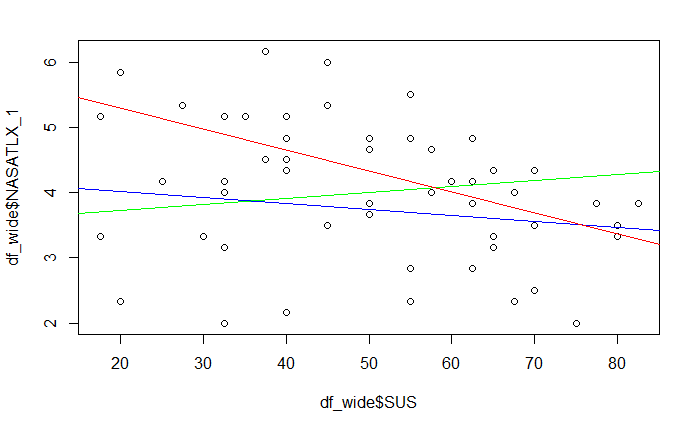

```r
df_control <- df_wide[(df_wide$group=="controlgroup"),]
df_exp_contextfree <- df_wide[(df_wide$group=="context-free experimental group"),]
df_exp_context <- df_wide[(df_wide$group=="context-sensitive experimental group"),]
plot(df_wide$NASATLX_1~df_wide$SUS) + abline(lm(df_control$NASATLX_1~df_control$SUS), col="blue") + abline(lm(df_exp_contextfree$NASATLX_1~df_exp_contextfree$SUS), col="green") + abline(lm(df_exp_context$NASATLX_1~df_exp_context$SUS), col="red")
```

It turns out that the correlation is mostly pronounced (and only statistically significant) for the context-sensitive experimental group.

```r
pbcor(df_control$SUS,df_control$NASATLX_1)
```

```
Call:
pbcor(x = df_control$SUS, y = df_control$NASATLX_1)

Robust correlation coefficient: -0.1499
Test statistic: -0.6607
p-value: 0.51673
```

```r
pbcor(df_exp_contextfree$SUS,df_exp_contextfree$NASATLX_1)
```

```
Call:
pbcor(x = df_exp_contextfree$SUS, y = df_exp_contextfree$NASATLX_1)

Robust correlation coefficient: 0.1751
Test statistic: 0.5898
p-value: 0.56722
```

```r
pbcor(df_exp_context$SUS,df_exp_context$NASATLX_1)
```

```
Call:
pbcor(x = df_exp_context$SUS, y = df_exp_context$NASATLX_1)

Robust correlation coefficient: -0.6506
Test statistic: -3.7344
p-value: 0.00141
```

```
integer(0)
```

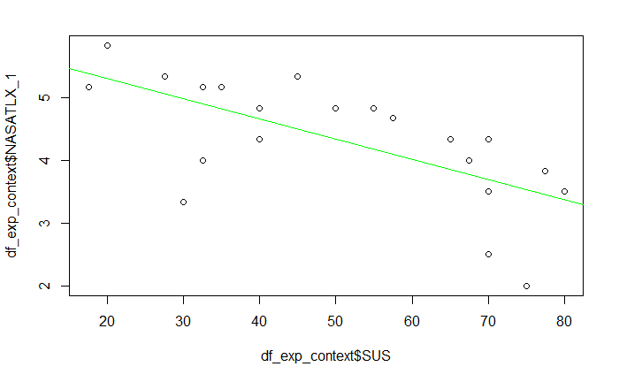

```r
# plotting NASA-TLX scores before the first interruption and SUS scores for the context-sensitive experimental group
plot(df_exp_context$NASATLX_1~df_exp_context$SUS)  + abline(lm(df_exp_context$NASATLX_1~df_exp_context$SUS), col="green")
```

When comparing the overall NASA-TLX score and the SUS scores between groups, a similar trend for the context-sensitive experimental group emerges.

```r
pbcor(df_control$SUS,df_control$NASATLX_mean)
```

```
Call:
pbcor(x = df_control$SUS, y = df_control$NASATLX_mean)

Robust correlation coefficient: 0.1186
Test statistic: 0.5207
p-value: 0.60862
```

```r
pbcor(df_exp_contextfree$SUS,df_exp_contextfree$NASATLX_mean)
```

```
Call:
pbcor(x = df_exp_contextfree$SUS, y = df_exp_contextfree$NASATLX_mean)

Robust correlation coefficient: 0.2421
Test statistic: 0.8276
p-value: 0.42548
```

```r
pbcor(df_exp_context$SUS,df_exp_context$NASATLX_mean)
```

```
Call:
pbcor(x = df_exp_context$SUS, y = df_exp_context$NASATLX_mean)

Robust correlation coefficient: -0.6649
Test statistic: -3.8805
p-value: 0.00101
```

```
integer(0)
```

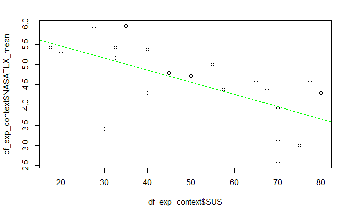

```r
plot(df_exp_context$NASATLX_mean~df_exp_context$SUS)  + abline(lm(df_exp_context$NASATLX_mean~df_exp_context$SUS), col="green")
```

#### Exploring the relation between SUS and NASA-TLX values for the context-sensitive group

For the context-sensitive experimental group, all correlations are significant: the higher the perceived usability, the lower the perceived mental workload.

```r
pbcor(df_exp_context$SUS,df_exp_context$NASATLX_2)
```

```
Call:
pbcor(x = df_exp_context$SUS, y = df_exp_context$NASATLX_2)

Robust correlation coefficient: -0.5789
Test statistic: -3.095
p-value: 0.00596
```

```r
pbcor(df_exp_context$SUS,df_exp_context$NASATLX_3)
```

```
Call:
pbcor(x = df_exp_context$SUS, y = df_exp_context$NASATLX_3)

Robust correlation coefficient: -0.4964
Test statistic: -2.4927
p-value: 0.02208
```

```r
pbcor(df_exp_context$SUS,df_exp_context$NASATLX_4)
```

```
Call:
pbcor(x = df_exp_context$SUS, y = df_exp_context$NASATLX_4)

Robust correlation coefficient: -0.654
Test statistic: -3.7683
p-value: 0.0013
```

#### Performance

There is no significant correlation between performance and SUS score, neither on a global nor on a group level.

```r
df_wide <- transform(df_wide, perf = mistakes_after_interruption / entries_after_interruption)
pbcor(df_wide$perf, df_wide$SUS)
```

```
Call:
pbcor(x = df_wide$perf, y = df_wide$SUS)

Robust correlation coefficient: 0.0616
Test statistic: 0.4496
p-value: 0.65482
```

Context-sensitive experimental group

```r
df_exp_context <- transform(df_exp_context, perf = mistakes_after_interruption / entries_after_interruption)
pbcor(df_exp_context$perf, df_exp_context$SUS)
```

```
Call:
pbcor(x = df_exp_context$perf, y = df_exp_context$SUS)

Robust correlation coefficient: 0.0113
Test statistic: 0.0492
p-value: 0.96126
```

Context-free experimental group

```r
df_exp_contextfree <- transform(df_exp_contextfree, perf = mistakes_after_interruption / entries_after_interruption)
pbcor(df_exp_contextfree$perf, df_exp_contextfree$SUS)
```

```
Call:
pbcor(x = df_exp_contextfree$perf, y = df_exp_contextfree$SUS)

Robust correlation coefficient: -0.479
Test statistic: -1.8097
p-value: 0.09772
```

Control group

```r
df_control <- transform(df_control, perf = mistakes_after_interruption / entries_after_interruption)
pbcor(df_control$perf, df_control$SUS)
```

```
Call:
pbcor(x = df_control$perf, y = df_control$SUS)

Robust correlation coefficient: 0.4203
Test statistic: 2.019
p-value: 0.05782
```

## Resumption speed

There is no significant correlation between resumption speed and SUS score, neither on a global nor on a group level.

```r
# global level
# compute resumption speed for each trial
df_wide$res_speed_1 <- 1/df_wide$resumption_lag_1
df_wide$res_speed_2 <- 1/df_wide$resumption_lag_2
df_wide$res_speed_3 <- 1/df_wide$resumption_lag_3
# compute correlations between SUS scores and resumption speed for each trial
pbcor(df_wide$SUS,df_wide$res_speed_1)
```

```
Call:
pbcor(x = df_wide$SUS, y = df_wide$res_speed_1)

Robust correlation coefficient: -0.1975
Test statistic: -1.4669
p-value: 0.1483
```

```r
pbcor(df_wide$SUS,df_wide$res_speed_2)
```

```
Call:
pbcor(x = df_wide$SUS, y = df_wide$res_speed_2)

Robust correlation coefficient: 4e-04
Test statistic: 0.0029
p-value: 0.99773
```

```r
pbcor(df_wide$SUS,df_wide$res_speed_3)
```

```
Call:
pbcor(x = df_wide$SUS, y = df_wide$res_speed_3)

Robust correlation coefficient: 0.0555
Test statistic: 0.4047
p-value: 0.6873
```

```r
#Context-sensitive experimental group
# compute resumption speed for each trial
df_exp_context$res_speed_1 <- 1/df_exp_context$resumption_lag_1
df_exp_context$res_speed_2 <- 1/df_exp_context$resumption_lag_2
df_exp_context$res_speed_3 <- 1/df_exp_context$resumption_lag_3
# compute correlations between SUS scores and resumption speed for each trial
pbcor(df_exp_context$SUS,df_exp_context$res_speed_1)
```

```
Call:
pbcor(x = df_exp_context$SUS, y = df_exp_context$res_speed_1)

Robust correlation coefficient: -0.3492
Test statistic: -1.6241
p-value: 0.12082
```

```r
pbcor(df_exp_context$SUS,df_exp_context$res_speed_2)
```

```
Call:
pbcor(x = df_exp_context$SUS, y = df_exp_context$res_speed_2)

Robust correlation coefficient: -0.1606
Test statistic: -0.7092
p-value: 0.4868
```

```r
pbcor(df_exp_context$SUS,df_exp_context$res_speed_3)
```

```
Call:
pbcor(x = df_exp_context$SUS, y = df_exp_context$res_speed_3)

Robust correlation coefficient: -0.065
Test statistic: -0.284
p-value: 0.77951
```

```r
#Context-free experimental group
# compute resumption speed for each trial
df_exp_contextfree$res_speed_1 <- 1/df_exp_contextfree$resumption_lag_1
df_exp_contextfree$res_speed_2 <- 1/df_exp_contextfree$resumption_lag_2
df_exp_contextfree$res_speed_3 <- 1/df_exp_contextfree$resumption_lag_3
# compute correlations between SUS scores and resumption speed for each trial
pbcor(df_exp_contextfree$SUS,df_exp_contextfree$res_speed_1)
```

```
Call:
pbcor(x = df_exp_contextfree$SUS, y = df_exp_contextfree$res_speed_1)

Robust correlation coefficient: -0.1924
Test statistic: -0.6504
p-value: 0.52882
```

```r
pbcor(df_exp_contextfree$SUS,df_exp_contextfree$res_speed_2)
```

```
Call:
pbcor(x = df_exp_contextfree$SUS, y = df_exp_contextfree$res_speed_2)

Robust correlation coefficient: 0.2444
Test statistic: 0.8358
p-value: 0.42105
```

```r
pbcor(df_exp_contextfree$SUS,df_exp_contextfree$res_speed_3)
```

```
Call:
pbcor(x = df_exp_contextfree$SUS, y = df_exp_contextfree$res_speed_3)

Robust correlation coefficient: 0.1293
Test statistic: 0.4325
p-value: 0.6737
```

```r
#Control group
# compute resumption speed for each trial
df_control$res_speed_1 <- 1/df_control$resumption_lag_1
df_control$res_speed_2 <- 1/df_control$resumption_lag_2
df_control$res_speed_3 <- 1/df_control$resumption_lag_3
# compute correlations between SUS scores and resumption speed for each trial
pbcor(df_control$SUS,df_control$res_speed_1)
```

```
Call:
pbcor(x = df_control$SUS, y = df_control$res_speed_1)

Robust correlation coefficient: 0.0317
Test statistic: 0.1381
p-value: 0.89164
```

```r
pbcor(df_control$SUS,df_control$res_speed_2)
```

```
Call:
pbcor(x = df_control$SUS, y = df_control$res_speed_2)

Robust correlation coefficient: 0.1092
Test statistic: 0.479
p-value: 0.63737
```

```r
pbcor(df_control$SUS,df_control$res_speed_3)
```

```
Call:
pbcor(x = df_control$SUS, y = df_control$res_speed_3)

Robust correlation coefficient: 0.1522
Test statistic: 0.6714
p-value: 0.51007
```

## List input lags

There is no significant correlation between list input lags and SUS score, neither on a global nor on a group level.

```r
# global level
# compute correlations between SUS scores and list input lags for each trial
pbcor(df_wide$SUS,df_wide$list_input_lag_1)
```

```
Call:
pbcor(x = df_wide$SUS, y = df_wide$list_input_lag_1)

Robust correlation coefficient: 0.0927
Test statistic: 0.6582
p-value: 0.51345
```

```r
pbcor(df_wide$SUS,df_wide$list_input_lag_2)
```

```
Call:
pbcor(x = df_wide$SUS, y = df_wide$list_input_lag_2)

Robust correlation coefficient: 0.2129
Test statistic: 1.5094
p-value: 0.13776
```

```r
pbcor(df_wide$SUS,df_wide$list_input_lag_3)
```

```
Call:
pbcor(x = df_wide$SUS, y = df_wide$list_input_lag_3)

Robust correlation coefficient: -0.2171
Test statistic: -1.4751
p-value: 0.14729
```

```r
# Control group
# compute correlations between SUS scores and list input lags for each trial
pbcor(df_control$SUS,df_control$list_input_lag_1)
```

```
Call:
pbcor(x = df_control$SUS, y = df_control$list_input_lag_1)

Robust correlation coefficient: 0.26
Test statistic: 1.1425
p-value: 0.26821
```

```r
pbcor(df_control$SUS,df_control$list_input_lag_2)
```

```
Call:
pbcor(x = df_control$SUS, y = df_control$list_input_lag_2)

Robust correlation coefficient: 0.3113
Test statistic: 1.3897
p-value: 0.18156
```

```r
pbcor(df_control$SUS,df_control$list_input_lag_3)
```

```
Call:
pbcor(x = df_control$SUS, y = df_control$list_input_lag_3)

Robust correlation coefficient: -0.221
Test statistic: -0.8774
p-value: 0.39409
```

```r
# context-sensitive experimental group
# compute correlations between SUS scores and list input lags for each trial
pbcor(df_exp_context$SUS,df_exp_context$list_input_lag_1)
```

```
Call:
pbcor(x = df_exp_context$SUS, y = df_exp_context$list_input_lag_1)

Robust correlation coefficient: -0.1593
Test statistic: -0.6847
p-value: 0.50224
```

```r
pbcor(df_exp_context$SUS,df_exp_context$list_input_lag_2)
```

```
Call:
pbcor(x = df_exp_context$SUS, y = df_exp_context$list_input_lag_2)

Robust correlation coefficient: 0.0519
Test statistic: 0.2078
p-value: 0.83802
```

```r
pbcor(df_exp_context$SUS,df_exp_context$list_input_lag_3)
```

```
Call:
pbcor(x = df_exp_context$SUS, y = df_exp_context$list_input_lag_3)

Robust correlation coefficient: -0.1032
Test statistic: -0.4148
p-value: 0.68378
```

```r
#context-free experimental group
# compute correlations between SUS scores and list input lags for each trial
pbcor(df_exp_contextfree$SUS,df_exp_contextfree$list_input_lag_1)
```

```
Call:
pbcor(x = df_exp_contextfree$SUS, y = df_exp_contextfree$list_input_lag_1)

Robust correlation coefficient: 0.1754
Test statistic: 0.5636
p-value: 0.58547
```

```r
pbcor(df_exp_contextfree$SUS,df_exp_contextfree$list_input_lag_2)
```

```
Call:
pbcor(x = df_exp_contextfree$SUS, y = df_exp_contextfree$list_input_lag_2)

Robust correlation coefficient: 0.2506
Test statistic: 0.8185
p-value: 0.43212
```

```r
pbcor(df_exp_contextfree$SUS,df_exp_contextfree$list_input_lag_3)
```

```
Call:
pbcor(x = df_exp_contextfree$SUS, y = df_exp_contextfree$list_input_lag_3)

Robust correlation coefficient: -0.3328
Test statistic: -1.0589
p-value: 0.31723
```

## purposeful action lags

There is no significant correlation between purposeful action lags and SUS score.

```r
# df without control group
df_exp <- df_wide[!(df_wide$group=="controlgroup"),]
# convert group and trial to factors
df_exp$group <- factor(df_exp$group)
# log-transform purposeful action lags to achieve better distribution characteristics
df_exp$ppa_log_1 <- log(df_exp$purposeful_action_lag_1)
df_exp$ppa_log_2 <- log(df_exp$purposeful_action_lag_2)
df_exp$ppa_log_3 <- log(df_exp$`purposeful_action_lag.3`)
## compute correlations
cor.test(df_exp$ppa_log_1, df_exp$SUS, use='complete.obs')
```

```
    Pearson's product-moment correlation

data:  df_exp$ppa_log_1 and df_exp$SUS
t = -1.1793, df = 32, p-value = 0.247
alternative hypothesis: true correlation is not equal to 0
95 percent confidence interval:
 -0.5072422  0.1440219
sample estimates:
       cor
-0.2040834
```

```r
cor.test(df_exp$ppa_log_2, df_exp$SUS, use='complete.obs')
```

```
    Pearson's product-moment correlation

data:  df_exp$ppa_log_2 and df_exp$SUS
t = -1.3148, df = 32, p-value = 0.1979
alternative hypothesis: true correlation is not equal to 0
95 percent confidence interval:
 -0.5244101  0.1210401
sample estimates:
       cor
-0.2263922
```

```r
cor.test(df_exp$ppa_log_3, df_exp$SUS, use='complete.obs')
```

```
    Pearson's product-moment correlation

data:  df_exp$ppa_log_3 and df_exp$SUS
t = -1.7711, df = 30, p-value = 0.0867
alternative hypothesis: true correlation is not equal to 0
95 percent confidence interval:
 -0.59277220  0.04595069
sample estimates:
      cor
-0.307673
```